# Supermarket Data analysis

## INTRODUCTION

In this analysis, we perform a detailed assessment of a supermarket sales dataset that we got from Kaggle. The dataset contains detailed information on product lines, payment methods, customer demographics, and sales transactions, with a total of 1000 entries and 17 columns. Our objective is to get relevant data and identify significant patterns that will support the store's strategic decision-making.

Our objectives are to detect patterns in customer behaviour, understand the effectiveness of different product categories, assess the usefulness of substitute payment methods, and look into how a customer's membership status affects sales through thorough data analysis. We will also examine factors like total revenue, peak transaction hours, and sales dispersion throughout different cities in order to provide a complete picture of the supermarket's operations.

With this study, we want to provide useful data that will, by directing marketing tactics, enhancing operational performance, and optimising inventory management, help the supermarket thrive in a competitive market.

Let's take a close look at the data to uncover any patterns that might help our business become more profitable and expand.

```python
# import required library
import pandas as pd
import numpy as np
import matplotlib.pyplot as plt
import seaborn as sns
```

```python
# loading the dataset
supermarket = pd.read_csv('C:/Users/HP/OneDrive/Desktop/Brainwave/supermarket_sales.csv')
```

```python
# checking the data
supermarket
```

|  | Invoice ID | Branch | City | Customer type | Gender | Product line | Unit price | Quantity | Tax 5% | Total | Date | Time | Payment | cogs | gross margin percentage | gross income | Rating |
| --- | --- | --- | --- | --- | --- | --- | --- | --- | --- | --- | --- | --- | --- | --- | --- | --- | --- |
| 0 | 750-67-8428 | A | Yangon | Member | Female | Health and beauty | 74.69 | 7 | 26.1415 | 548.9715 | 1/5/2019 | 13:08 | Ewallet | 522.83 | 4.761905 | 26.1415 | 9.1 |
| 1 | 226-31-3081 | C | Naypyitaw | Normal | Female | Electronic accessories | 15.28 | 5 | 3.8200 | 80.2200 | 3/8/2019 | 10:29 | Cash | 76.40 | 4.761905 | 3.8200 | 9.6 |
| 2 | 631-41-3108 | A | Yangon | Normal | Male | Home and lifestyle | 46.33 | 7 | 16.2155 | 340.5255 | 3/3/2019 | 13:23 | Credit card | 324.31 | 4.761905 | 16.2155 | 7.4 |
| 3 | 123-19-1176 | A | Yangon | Member | Male | Health and beauty | 58.22 | 8 | 23.2880 | 489.0480 | 1/27/2019 | 20:33 | Ewallet | 465.76 | 4.761905 | 23.2880 | 8.4 |
| 4 | 373-73-7910 | A | Yangon | Normal | Male | Sports and travel | 86.31 | 7 | 30.2085 | 634.3785 | 2/8/2019 | 10:37 | Ewallet | 604.17 | 4.761905 | 30.2085 | 5.3 |
| ... | ... | ... | ... | ... | ... | ... | ... | ... | ... | ... | ... | ... | ... | ... | ... | ... | ... |
| 995 | 233-67-5758 | C | Naypyitaw | Normal | Male | Health and beauty | 40.35 | 1 | 2.0175 | 42.3675 | 1/29/2019 | 13:46 | Ewallet | 40.35 | 4.761905 | 2.0175 | 6.2 |
| 996 | 303-96-2227 | B | Mandalay | Normal | Female | Home and lifestyle | 97.38 | 10 | 48.6900 | 1022.4900 | 3/2/2019 | 17:16 | Ewallet | 973.80 | 4.761905 | 48.6900 | 4.4 |
| 997 | 727-02-1313 | A | Yangon | Member | Male | Food and beverages | 31.84 | 1 | 1.5920 | 33.4320 | 2/9/2019 | 13:22 | Cash | 31.84 | 4.761905 | 1.5920 | 7.7 |
| 998 | 347-56-2442 | A | Yangon | Normal | Male | Home and lifestyle | 65.82 | 1 | 3.2910 | 69.1110 | 2/22/2019 | 15:33 | Cash | 65.82 | 4.761905 | 3.2910 | 4.1 |
| 999 | 849-09-3807 | A | Yangon | Member | Female | Fashion accessories | 88.34 | 7 | 30.9190 | 649.2990 | 2/18/2019 | 13:28 | Cash | 618.38 | 4.761905 | 30.9190 | 6.6 |

1000 rows × 17 columns

```python
# checkin data type
supermarket.info()
```

```
<class 'pandas.core.frame.DataFrame'>
RangeIndex: 1000 entries, 0 to 999
Data columns (total 17 columns):
 #   Column                   Non-Null Count  Dtype
---  ------                   --------------  -----
 0   Invoice ID               1000 non-null   object
 1   Branch                   1000 non-null   object
 2   City                     1000 non-null   object
 3   Customer type            1000 non-null   object
 4   Gender                   1000 non-null   object
 5   Product line             1000 non-null   object
 6   Unit price               1000 non-null   float64
 7   Quantity                 1000 non-null   int64
 8   Tax 5%                   1000 non-null   float64
 9   Total                    1000 non-null   float64
 10  Date                     1000 non-null   object
 11  Time                     1000 non-null   object
 12  Payment                  1000 non-null   object
 13  cogs                     1000 non-null   float64
 14  gross margin percentage  1000 non-null   float64
 15  gross income             1000 non-null   float64
 16  Rating                   1000 non-null   float64
dtypes: float64(7), int64(1), object(9)
memory usage: 132.9+ KB
```

```python
# checking the top rows(10)
supermarket.head(10)
```

|  | Invoice ID | Branch | City | Customer type | Gender | Product line | Unit price | Quantity | Tax 5% | Total | Date | Time | Payment | cogs | gross margin percentage | gross income | Rating |
| --- | --- | --- | --- | --- | --- | --- | --- | --- | --- | --- | --- | --- | --- | --- | --- | --- | --- |
| 0 | 750-67-8428 | A | Yangon | Member | Female | Health and beauty | 74.69 | 7 | 26.1415 | 548.9715 | 1/5/2019 | 13:08 | Ewallet | 522.83 | 4.761905 | 26.1415 | 9.1 |
| 1 | 226-31-3081 | C | Naypyitaw | Normal | Female | Electronic accessories | 15.28 | 5 | 3.8200 | 80.2200 | 3/8/2019 | 10:29 | Cash | 76.40 | 4.761905 | 3.8200 | 9.6 |
| 2 | 631-41-3108 | A | Yangon | Normal | Male | Home and lifestyle | 46.33 | 7 | 16.2155 | 340.5255 | 3/3/2019 | 13:23 | Credit card | 324.31 | 4.761905 | 16.2155 | 7.4 |
| 3 | 123-19-1176 | A | Yangon | Member | Male | Health and beauty | 58.22 | 8 | 23.2880 | 489.0480 | 1/27/2019 | 20:33 | Ewallet | 465.76 | 4.761905 | 23.2880 | 8.4 |
| 4 | 373-73-7910 | A | Yangon | Normal | Male | Sports and travel | 86.31 | 7 | 30.2085 | 634.3785 | 2/8/2019 | 10:37 | Ewallet | 604.17 | 4.761905 | 30.2085 | 5.3 |
| 5 | 699-14-3026 | C | Naypyitaw | Normal | Male | Electronic accessories | 85.39 | 7 | 29.8865 | 627.6165 | 3/25/2019 | 18:30 | Ewallet | 597.73 | 4.761905 | 29.8865 | 4.1 |
| 6 | 355-53-5943 | A | Yangon | Member | Female | Electronic accessories | 68.84 | 6 | 20.6520 | 433.6920 | 2/25/2019 | 14:36 | Ewallet | 413.04 | 4.761905 | 20.6520 | 5.8 |
| 7 | 315-22-5665 | C | Naypyitaw | Normal | Female | Home and lifestyle | 73.56 | 10 | 36.7800 | 772.3800 | 2/24/2019 | 11:38 | Ewallet | 735.60 | 4.761905 | 36.7800 | 8.0 |
| 8 | 665-32-9167 | A | Yangon | Member | Female | Health and beauty | 36.26 | 2 | 3.6260 | 76.1460 | 1/10/2019 | 17:15 | Credit card | 72.52 | 4.761905 | 3.6260 | 7.2 |
| 9 | 692-92-5582 | B | Mandalay | Member | Female | Food and beverages | 54.84 | 3 | 8.2260 | 172.7460 | 2/20/2019 | 13:27 | Credit card | 164.52 | 4.761905 | 8.2260 | 5.9 |

```python
# Check for missing values in each column and percentag
missing_values = supermarket.isnull().sum()
missing_percentage = supermarket.isnull().mean() * 100

print(missing_percentage)
print(missing_values)
```

```
Invoice ID                 0.0
Branch                     0.0
City                       0.0
Customer type              0.0
Gender                     0.0
Product line               0.0
Unit price                 0.0
Quantity                   0.0
Tax 5%                     0.0
Total                      0.0
Date                       0.0
Time                       0.0
Payment                    0.0
cogs                       0.0
gross margin percentage    0.0
gross income               0.0
Rating                     0.0
dtype: float64
Invoice ID                 0
Branch                     0
City                       0
Customer type              0
Gender                     0
Product line               0
Unit price                 0
Quantity                   0
Tax 5%                     0
Total                      0
Date                       0
Time                       0
Payment                    0
cogs                       0
gross margin percentage    0
gross income               0
Rating                     0
dtype: int64
```

without any missing value,we can proceed with our analysis

```python
# Check for duplicate rows and values
duplicates = supermarket.duplicated()
print(duplicates)

print(supermarket.duplicated().value_counts())
```

```
0      False
1      False
2      False
3      False
4      False
       ...
995    False
996    False
997    False
998    False
999    False
Length: 1000, dtype: bool
False    1000
dtype: int64
```

since no duplicate values,we can proceed

```python
# Calculate the average rating
average_rating = supermarket['Rating'].mean()

# Print the average rating
print(f"The average customer rating is: {average_rating:.3f}")
```

```
The average customer rating is: 6.973
```

```python
# Count occurrences of each gender
gender_count = supermarket['Gender'].value_counts()

# Print the count of each gender
print(gender_count)
```

```
Female    501
Male      499
Name: Gender, dtype: int64
```

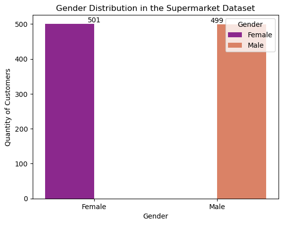

```python
# Create a count plot for gender distribution in the supermarket dataset
sns.countplot(x='Gender', data=supermarket, palette='plasma', hue='Gender')

# Add a title to the plot
plt.title('Gender Distribution in the Supermarket Dataset')

# Label the x-axis and y-axis
plt.xlabel('Gender')
plt.ylabel('Quantity of Customers')

# Retrieve counts for adding text labels
gender_counts = supermarket['Gender'].value_counts()

# Annotate each bar with the count value
for index, value in enumerate(gender_counts):
    plt.text(index, value, str(value), ha='center', va='bottom')

# Display the plot
plt.show()
```

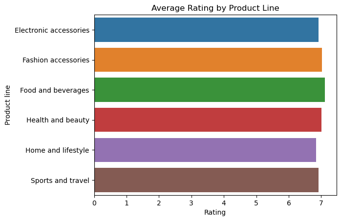

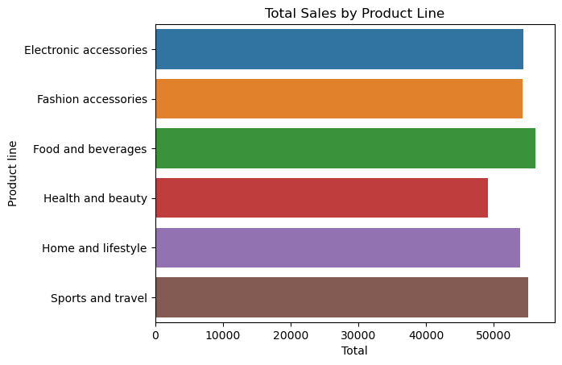

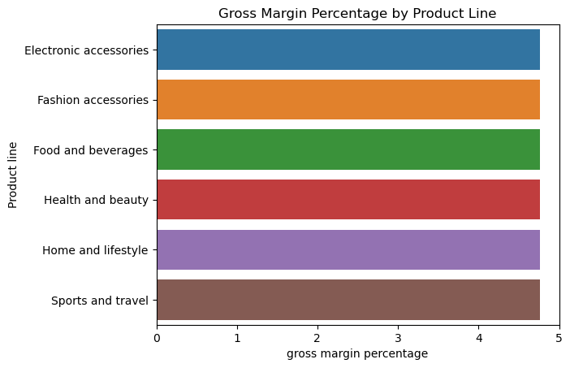

```python
# Average Rating by Product Line
rating_by_product_line = supermarket.groupby('Product line')['Rating'].mean().reset_index()
sns.barplot(x='Rating', y='Product line', data=rating_by_product_line)
plt.title('Average Rating by Product Line')
plt.show()

# Sales Performance by Product Line
product_line_sales = supermarket.groupby('Product line')['Total'].sum().reset_index()
sns.barplot(x='Total', y='Product line', data=product_line_sales)
plt.title('Total Sales by Product Line')
plt.show()


#Gross Margin Analysis
gross_margin_by_product_line = supermarket.groupby('Product line')['gross margin percentage'].mean().reset_index()
sns.barplot(x='gross margin percentage', y='Product line', data=gross_margin_by_product_line)
plt.title('Gross Margin Percentage by Product Line')
plt.show()
```

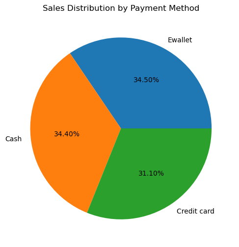

```python
# Sales Distribution by Payment Method
payment_method = supermarket['Payment'].value_counts().reset_index()
payment_method.columns = ['Payment Method', 'Count']
plt.figure(figsize=(6, 6))
plt.pie(payment_method['Count'], labels=payment_method['Payment Method'], autopct='%2.2f%%')
plt.title('Sales Distribution by Payment Method')
plt.show()
```

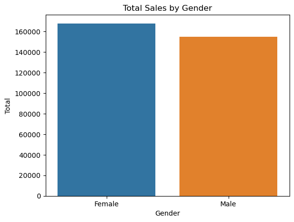

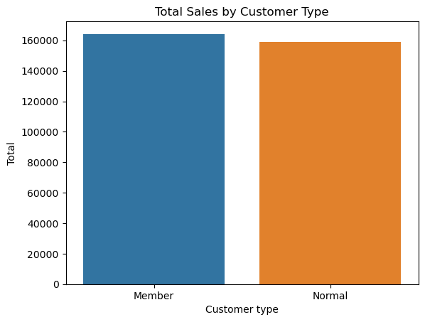

```python
# Customer Demographics: Gender and Customer Type

gender_sales = supermarket.groupby('Gender')['Total'].sum().reset_index()
sns.barplot(x='Gender', y='Total', data=gender_sales)
plt.title('Total Sales by Gender')
plt.show()

customer_type_sales = supermarket.groupby('Customer type')['Total'].sum().reset_index()
sns.barplot(x='Customer type', y='Total', data=customer_type_sales)
plt.title('Total Sales by Customer Type')
plt.show()
```

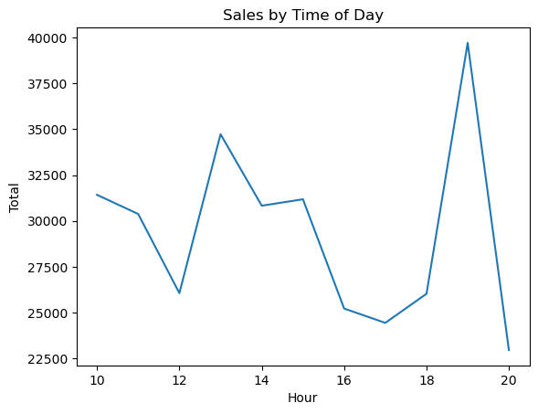

```python
#Sales by Time of Day
supermarket['Time'] = pd.to_datetime(supermarket['Time'])
supermarket['Hour'] = supermarket['Time'].dt.hour
sales_by_hour = supermarket.groupby('Hour')['Total'].sum().reset_index()
sns.lineplot(x='Hour', y='Total', data=sales_by_hour)
plt.title('Sales by Time of Day')
plt.show()
```

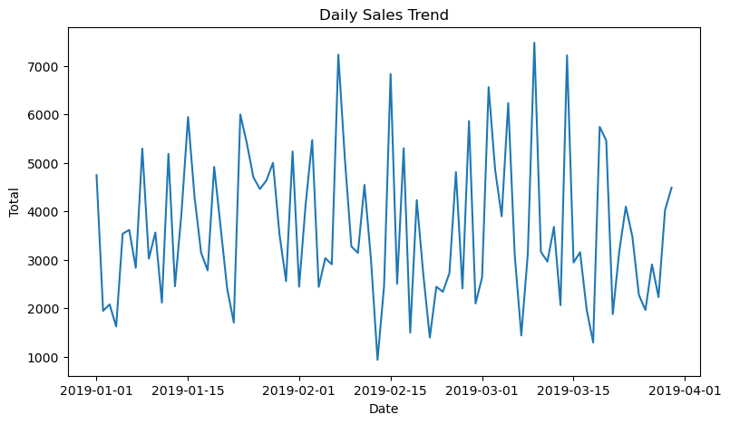

```python
# Sales Trend Over Time
supermarket['Date'] = pd.to_datetime(supermarket['Date'])
daily_sales = supermarket.groupby('Date')['Total'].sum().reset_index()
plt.figure(figsize=(9, 5))
sns.lineplot(x='Date', y='Total', data=daily_sales)
plt.title('Daily Sales Trend')
plt.show()
```

The relationship between sales, gender, and product line is shown bellow

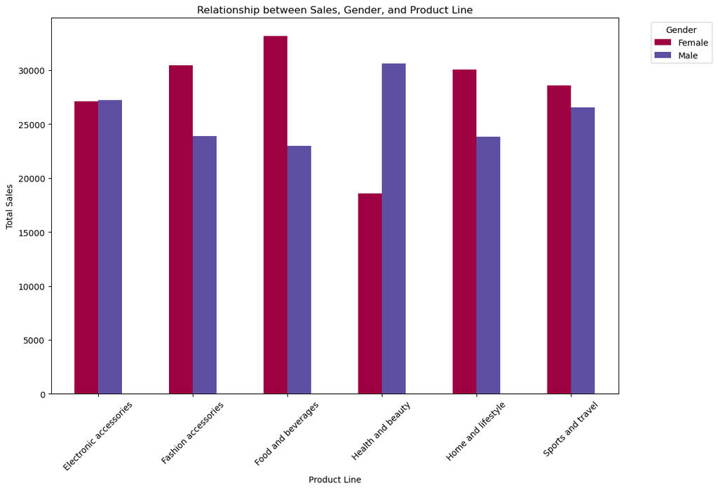

```python
# Group data by Product line and Gender and sum up Total sales
product_line_gender_sales = supermarket.groupby(['Product line', 'Gender'])['Total'].sum().unstack()

# Plot the relationship between sales, gender, and product line
plt.figure(figsize=(12, 8))
product_line_gender_sales.plot(kind='bar', stacked=False, colormap='Spectral', ax=plt.gca())
plt.title('Relationship between Sales, Gender, and Product Line')
plt.xlabel('Product Line')
plt.ylabel('Total Sales')
plt.xticks(rotation=45)
plt.legend(title='Gender', bbox_to_anchor=(1.05, 1), loc='upper left')
plt.show()
```

Sales vs Gross Income

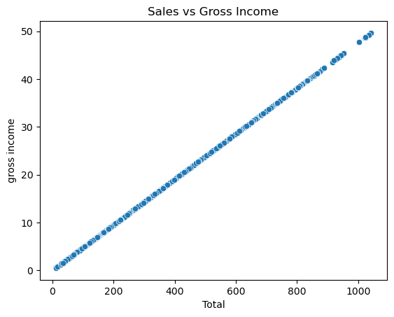

```python
# Sales vs. Gross Income
sns.scatterplot(x='Total', y='gross income', data=supermarket)
plt.title('Sales vs Gross Income')
plt.show()
```

Product sales distribution

```
Product line counts:  Fashion accessories       178
Food and beverages        174
Electronic accessories    170
Sports and travel         166
Home and lifestyle        160
Health and beauty         152
Name: Product line, dtype: int64
```

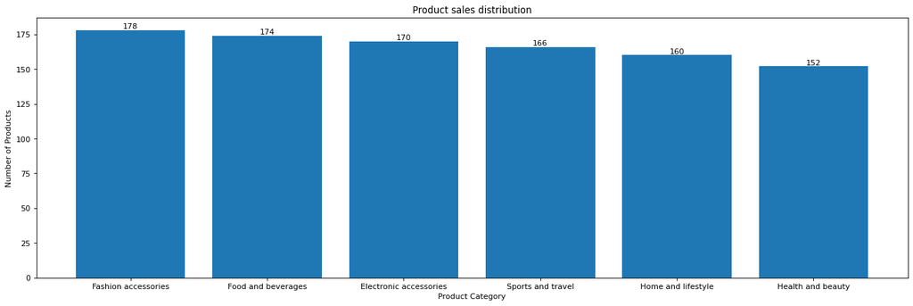

```python
# product line count
product_line_counts = supermarket['Product line'].value_counts()
print("Product line counts: ", product_line_counts)

# product sales distribution
plt.figure(figsize=(20, 6), dpi=80)
plt.bar(product_line_counts.index, product_line_counts.values)
plt.title('Product sales distribution')
plt.xlabel('Product Category')
plt.ylabel('Number of Products')
for index, value in enumerate(product_line_counts):
    plt.text(index, value, str(value), ha='center', va='bottom')
plt.show()
```

the above bar chat shows Relation between sales and product category,which Determines product category distribution in dataset

showing the payment distribution method can follow

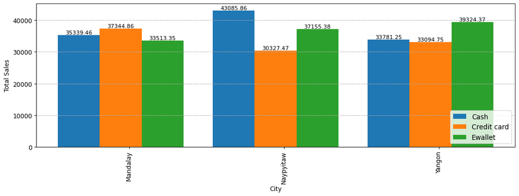

```python
# Group data by City and Payment, summing up Total sales
sales_by_city_payment = supermarket.groupby(['City', 'Payment'])['Total'].sum().unstack(fill_value=0)

# Determine the number of cities for plotting
num_cities = len(sales_by_city_payment.index)

# Set the bar width and create an index for each city
bar_width = 0.27
index = np.arange(num_cities)

# Create the plot with a specified figure size
plt.figure(figsize=(13, 5), dpi=80)

# Plot bars for each payment method
for i, payment_method in enumerate(sales_by_city_payment.columns):
    plt.bar(index + bar_width * i, sales_by_city_payment[payment_method], bar_width, label=payment_method)

# Labeling the axes and setting up ticks and grid
plt.xlabel('City', fontsize=11)
plt.ylabel('Total Sales', fontsize=11)
plt.xticks(index + bar_width * (len(sales_by_city_payment.columns) / 2 - 0.3), sales_by_city_payment.index, fontsize=11, rotation=90)
plt.yticks(fontsize=11)
plt.grid(axis='y', linestyle='--')

# Add legend to the plot
plt.legend(fontsize=12, loc='lower right')

# Add text annotations above each bar
for i, payment_method in enumerate(sales_by_city_payment.columns):
    for j, value in enumerate(sales_by_city_payment[payment_method]):
        plt.text(j + i * bar_width, value, str(round(value, 2)), ha='center', fontsize=10, verticalalignment='bottom')

# Adjust layout to prevent clipping of labels
plt.tight_layout()

# Display the plot
plt.show()
```

Correlation Heatmap

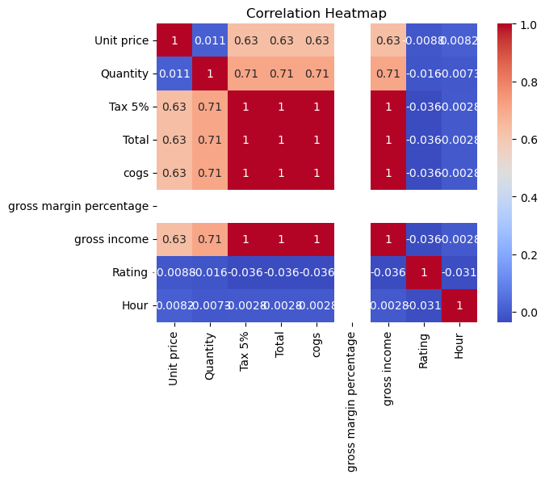

```python
#Correlation Heatmap
correlation_matrix = supermarket.corr()
sns.heatmap(correlation_matrix, annot=True, cmap='coolwarm')
plt.title('Correlation Heatmap')
plt.show()
```

### SUMMARY

Data Gathering and First Inspections: Data loading and library imports: The analysis starts with the import of many necessary libraries, such as seaborn, matplotlib.pyplot, pandas, and numpy. To load the dataset, use pd.read_csv(). Initial Data Examination: supermarket.info() is used to investigate data types, supermarket.head(10) is used to preview the first 10 rows, and the dataset is shown as part of basic data checks. Check for Missing Values: The analysis determines the proportion of missing data by using supermarket.isnull().sum() to evaluate the missing values in each column. The analysis continues as no meaningful missing data were discovered. Check for Duplicate Values: To make sure there are no duplicate entries, duplicate rows are enumerated and examined using supermarket.duplicated().

Analysis of Sales and Payments: Sales Distribution by Payment Method: A pie chart displays the sales distribution among various payment methods, indicating the preferred mode of payment for clients. Customer Demographics: To identify spending trends among various customer groupings, total sales are split down by gender and customer type and visualised using bar charts. Sales by Time of Day: To determine the busiest shopping hours, sales data is compiled each hour and plotted on a line. Sales Trend Over Time: To identify patterns over time, daily sales trends are examined by adding up all of the sales for each day. The trend is then plotted on a line plot.

The inquiry yields valuable insights into customer behaviour, product performance, and sales patterns. This information may be used to improve operational effectiveness, refine product offerings, and optimise marketing strategies.

### RECOMMENDATIONS

Optimise Product Offerings: The information reveals that different product lines have different average ratings and sales results. While assessing and enhancing underperforming product lines, concentrate on marketing top-performing ones. This might entail making changes to inventory, improving marketing initiatives, or launching specials to increase sales of underperforming goods.

Customise Marketing Plans Based on Population: Different spending habits may be seen when sales are broken down by customer type and gender. Create specialised advertising campaigns by using these information. For example, if some product lines work better with particular client kinds or genders, make customised ads and promotions to better target these groups.

Utilise Sales Trends for Inventory Management: Sales data over time and by time of day reveal patterns in the purchase habits of customers. Make the most of workforce and inventory management by using this information. Achieve optimal customer service and well-stocked high-demand items by coordinating staff schedules and stock levels with peak shopping hours and seasonal patterns.